# Brownian local times

Tue Oct 6 15:52:41 2015

$$\newcommand{\E}{\mathbb{E}}
\renewcommand{\P}{\mathbb{P}}
\DeclareMathOperator{\sgn}{sgn}$$

# Killing at Brownian local times

It states in [Takacs](https://projecteuclid.org/euclid.aoap/1177004703) that if $\ell(x)$ is the local time at $x$ for Brownian motion run for time 1 and begun at 0, i.e.,
$$\begin{aligned}
\ell(x) = \lim_{\epsilon \to 0} \frac{1}{\epsilon}
\text{measure}\{t \,:\, x \le B_t \le x+\epsilon, \, 0 \le t \le 1\}
\end{aligned}$$
then
$$\begin{aligned}
\P\{ \ell(x) \le u \} = 2 \Phi(|x|+u)-1,
\end{aligned}$$
where $\Phi(x)=\P\{B_1 \le x\}$ is the Gaussian CDF. Differentiating this, $\P\{\ell \in du\} = \partial_u \P\{\ell \le u\}$, so
$$\begin{aligned}
\P\{ \ell(x) = 0 \} &= 2 \Phi(|x|)-1 \\
\P\{ \ell(x) \in du \} &= 2 \phi(|x|+u) ,
\end{aligned}$$
where $\phi$ is the Gaussian density.

Let's check this:

```r
nwalks <- 1e4
ntimes <- 1e3
# want total time to be 1, so:
eps <- 1/sqrt(ntimes)
rws <- matrix( rnorm(nwalks*ntimes)*eps, nrow=ntimes, ncol=nwalks )
rws <- rbind(0,apply(rws,2,cumsum))
matplot(seq(0,1,length.out=ntimes),rws[,1:20],type='l', ylab='position')
```

[output not shown]

Here we've simulated 10<sup>4</sup> random walks for a total of 1000 steps, and scaled steps to have this be a total Brownian time of 1. Let's check; this should just be a standard Gaussian:

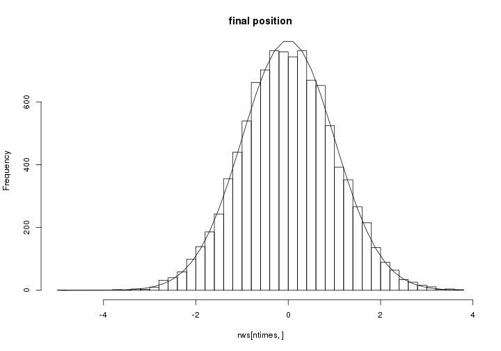

```r
xh <- hist(rws[ntimes,],breaks=50,main="final position")
lines( xh$mids, sum(xh$counts)*diff(pnorm(xh$breaks)) )
```

Now, let's check on the local time formula. The number of steps the random walk spends at position $k$ on a grid with spacing $\epsilon$ and a time step of should be $\epsilon \times \ell(k\epsilon) / \gamma$. First, the local time at 0:

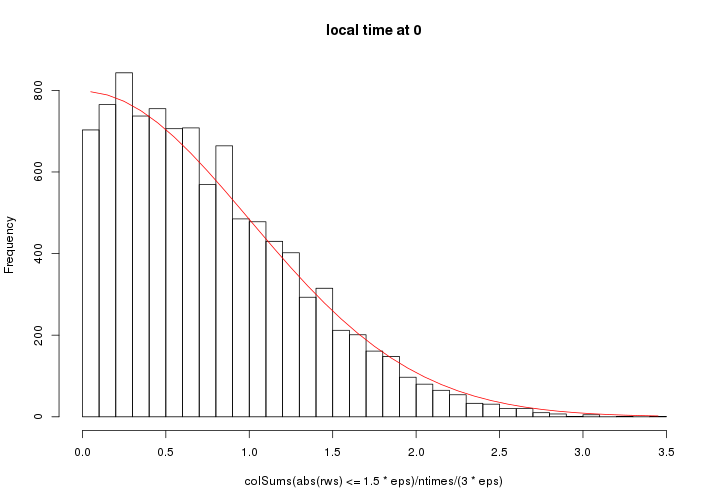

```r
xh <- hist(colSums(abs(rws)<=1.5*eps)/ntimes/(3*eps),main="local time at 0", breaks=30)
lines( xh$mids, sum(xh$counts)*diff( 2*pnorm(xh$breaks)-1 ), col='red' )
```

What about the local time at other locations? Note there is an atom at 0 now (that is depicted by the dots in the figures below), and that the discretization could trip us up; the colors (red/green/blue) use the (mid/upper/lower) points of the interval that we count in.

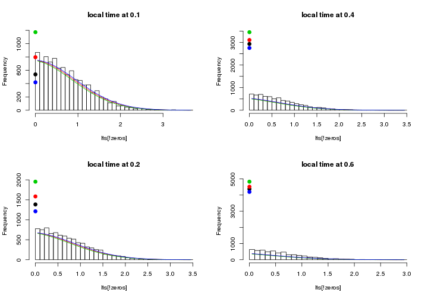

```r
layout(matrix(1:4,nrow=2))
for (loc in c(0.1, 0.2, 0.4, 0.6)) {
    lts <- colSums(abs(rws-loc)<=1.5*eps)/ntimes/(3*eps)
    zeros <- (lts==0)
    pred.zero <- 2*pnorm(abs(loc)+c(0,1.5*eps,-1.5*eps))-1
    xh <- hist(lts[!zeros],main=paste("local time at",loc), breaks=30, ylim=range(c(0,pred.zero*nwalks)))
    lines( xh$mids, sum(!zeros)*diff( 2*pnorm(abs(loc)+xh$breaks)-1 ), col='red' )
    points(rep(0,4), c(sum(zeros),pred.zero*nwalks), col=1:4, pch=20, cex=2)
    # lower bound
    lines( xh$mids, sum(!zeros)*diff( 2*pnorm(abs(loc+1.5*eps)+xh$breaks)-1 ), col=3 )
    # upper bound
    lines( xh$mids, sum(!zeros)*diff( 2*pnorm(abs(loc-1.5*eps)+xh$breaks)-1 ), col=4 )
}
```

Clearly, the discretization is still tripping us up a bit, but it's pretty good.

# Its Laplace transform

Now suppose that something happens at rate $r$ relative to the local time at $x$ (e.g., recombination to the other background). Then the chance that this has not happened by time 1 is
$$\begin{aligned}
\zeta(x,r) &:=
\E\left[ e^{-r\ell(x)} \right] \\
&=
2\Phi(|x|)-1 +
\int_0^\infty e^{-rt} 2 \phi(|x|+t) dt \\
&=
2\Phi(|x|)-1 +
e^{r|x|} \int_{|x|}^\infty e^{-rt} 2 \phi(t) dt \\
&=
2\Phi(|x|)-1 +
2 e^{r|x|} \int_{|x|}^\infty \frac{1}{\sqrt{2\pi}} \exp\left( - rt - t^2/2 \right) dt \\
&=
2\Phi(|x|)-1 +
2 e^{r|x|+r^2/2} \int_{|x|}^\infty \frac{1}{\sqrt{2\pi}} \exp\left( - (t+r)^2/2 \right) dt \\
&=
2\Phi(|x|)-1 +
2 e^{r|x|+r^2/2} \left( 1-\Phi(|x|+r) \right) .
\end{aligned}$$
At $r=0$ this equals 1, as it should, since it's the chance that nothing happens. For large $x$, since $1-\Phi(x) \sim e^{-x^2/2}/\sqrt{2\pi}x$, this is approximately $1 + 2 \exp( r|x| + r^2/2 - (|x|+r)^2/2 )$, which goes to 1, as it should.

Let's check that, too: why not?

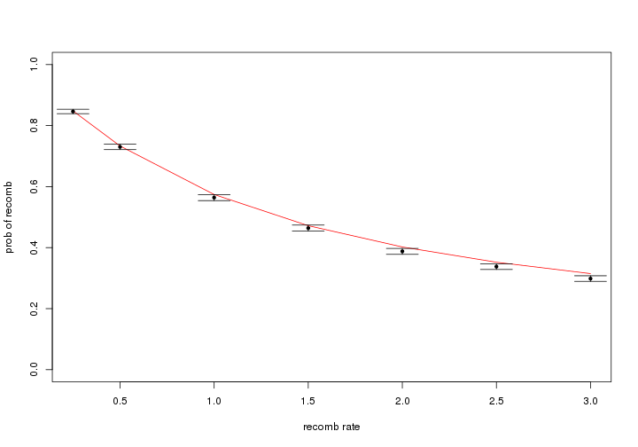

```r
loc <- 0.1
zeta <- function (x,r) {
    2*pnorm(abs(x)) - 1 + 2 * exp( r*abs(x) + r^2/2 + pnorm(abs(x)+r,lower.tail=FALSE,log.p=TRUE) )
}
compare.rates <- as.data.frame( t( sapply( c(0.25,0.5,1,1.5,2,2.5,3), function (rate) {
        visits <- colSums(abs(rws-loc)<=1.5*eps)
        killed <- ( rbinom(ncol(rws),size=visits,prob=rate/ntimes/(3*eps)) == 0 )
        c(
          rate=rate,
          simulation=mean(killed),
          theory=zeta(loc,rate),
          SE=sqrt(mean(killed)*(1-mean(killed))/nwalks)
          )
    } ) ) )
with(compare.rates, {
         plot( rate, theory, type='l', xlab="recomb rate", ylab="prob of recomb", col='red', ylim=c(0,1) )
         points( rate, simulation, pch=20 )
         arrows( x0=rate, y0=simulation-2*SE, y1=simulation+2*SE, angle=90, code=3 )
    } )
```

This is very steep at $x=0$. Notice that as $x$ goes to 0,
$$\begin{aligned}
\lim_{x \to 0} \zeta(x,r)
&= 2 e^{r^2/2} (1-\Phi(r)) \\
&= \frac{2}{r\sqrt{2\pi}} + O(r^{-3}) .
\end{aligned}$$
so that the difference in the left and right limits is
$$\begin{aligned}
\lim_{x \to 0-} p(x,r)
-\lim_{x \to 0+} p(x,r)
&=
\frac{1}{2}+\frac{2}{r\sqrt{2\pi}}
- \frac{1}{2}-\frac{2}{r\sqrt{2\pi}}
+O(r^{-3}) \\
&=
\frac{4}{r\sqrt{2\pi}}
+O(r^{-3})
\end{aligned}$$

Let's also look at the slope of $p$ at $x=0$. Since $\partial_x |x| = \sgn(x)$,
$$\begin{aligned}
\partial_x \zeta(x,r)
&=
2 \sgn(x) \left(
\phi(|x|)
+ r e^{r|x|+r^2/2} (1-\Phi(|x|+r))
- e^{r|x|+r^2/2} \phi(|x|+r)
\right)
\end{aligned}$$
and so
$$\begin{aligned}
-\partial_x p(x)
&=
\phi(|x|)
+ r e^{r|x|+r^2/2} (1-\Phi(|x|+r))
- e^{r|x|+r^2/2} \phi(|x|+r) \\
&\to
\frac{1}{\sqrt{2\pi}}(1-e^{r^2/2}e^{-r^2/2})
+ r e^{r^2/2} (1-\Phi(r)) \qquad \text{as } x \to 0 \\
&=
r e^{r^2/2} (1-\Phi(r)) \\
&=
\frac{1}{\sqrt{2\pi}} + O(\frac{1}{r}) .
\end{aligned}$$

Also note that for large $|x|$, by the asymptotics for $1-\Phi(x)$,
$$\begin{aligned}
\zeta(x,r) = 1 - \sqrt{\frac{2}{\pi}} e^{-x^2/2} \left( \frac{r}{x+r} \right) .
\end{aligned}$$

# What this says about clines

The above restricted to standard Brownian motion on one unit of time. Really, we will want to use this across $\tau$ generations, modeling a random walk with variance $\sigma^2$ per generation.

The key quantity we want is the probability that a Brownian motion with variance $\sigma^2$ killed at rate $r$ with respect to its local time at $x$ was still alive at time $\tau$. Denote this by
$$\begin{aligned}
\zeta(x,r,\tau,\sigma).
\end{aligned}$$
By Brownian scaling, since $B_{ct}$ has the same distribution as $\sqrt{c}B_t$,
$$\begin{aligned}
\zeta(x,r,\tau,\sigma)
&=
\zeta(x,r\tau,1,\sqrt{\tau}\sigma) \\
&=
\zeta(x/\sqrt{\tau\sigma^2},r\tau) ,
\end{aligned}$$
where
$$\begin{aligned}
\zeta(x,r)
&=
1 - 2(1-\Phi(|x|)) +
2 e^{r|x|+r^2/2} \left( 1-\Phi(|x|+r) \right) .
\end{aligned}$$

**Cline flattening:** immediately, this tells us how a cline gets wider as time progresses: for a fixed $r$, the width grows as $\sqrt{\tau}$. It also tells us that clines with the same $r\tau$ have the same shape, after rescaling the width by $\sqrt{\tau}$. Also, this tells us we only have a cline for $r$ of order at least $1/\tau$: for smaller $r$, the locus is still completely linked to the selected locus, and hence a step function.

More generally, here's what $\zeta$ looks like:

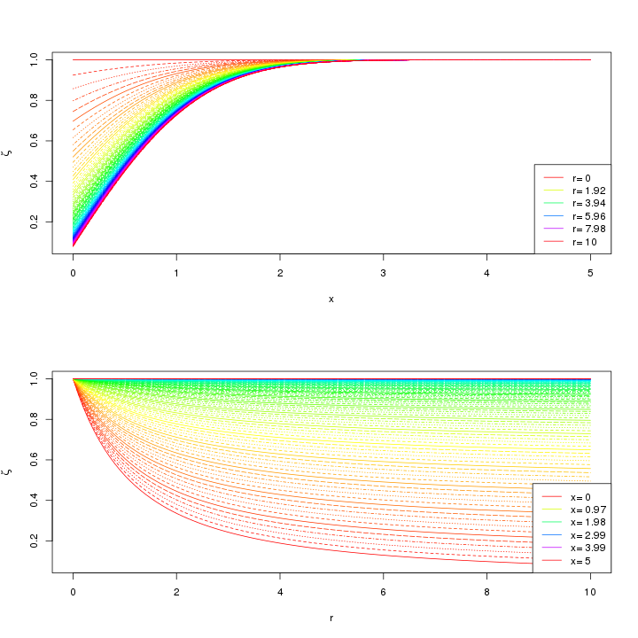

```r
layout(1:2)
xvals <- seq(0,5,length.out=150)
rvals <- seq(0,10,length.out=100)
zetavals <- outer( xvals, rvals, zeta )
matplot(xvals,zetavals,type='l',xlab="x",ylab=expression(zeta),col=rainbow(length(rvals)))
lrvals <- seq(1,length(rvals),length.out=6)
legend("bottomright",lty=1,col=rainbow(length(rvals))[lrvals],legend=paste("r=",round(rvals[lrvals],digits=2)))
matplot(rvals,t(zetavals),type='l',xlab="r",ylab=expression(zeta),col=rainbow(length(xvals)))
lxvals <- seq(1,length(xvals),length.out=6)
legend("bottomright",lty=1,col=rainbow(length(xvals))[lxvals],legend=paste("x=",round(xvals[lxvals],digits=2)),bg='white')
```

Now, let $p(x,r,\tau,A)$ denote the probability that a lineage begun at $x<0$ at a location at recombination distance $r$ from the selected site inherits from the left-hand side of the barrier (i.e., an ancestor on $(-\infty,0)$) $\tau$ generations ago. (Note that $r$ should be scaled by the density and fecundity of heterozygotes in the cline -- see below.) For an individual to the left of the barrier ($x<0$), the probability of inheriting from the left of the barrier at $\tau$ is the probability that no recombination at the barrier has occurred, plus one-half the probability that recombination in a heterozygote has occurred, i.e., $\zeta +(1-\zeta)/2=(1+\zeta)/2$. If $x>0$ this is the one-half times probability a recombination in a heterozygote has occurred, i.e., $(1-\zeta)/2$. Combining these, the probability of ending up on the left-hand side is
$$\begin{aligned}
p(x,r,\tau,A) =
\frac{1}{2} \left\{ 1 - \sgn(x) \zeta(x,r,\tau) \right\} .
\end{aligned}$$

Here's the cline shape:

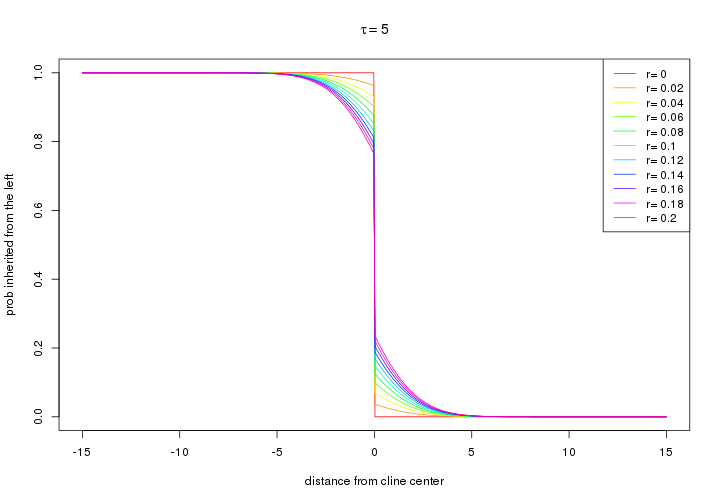

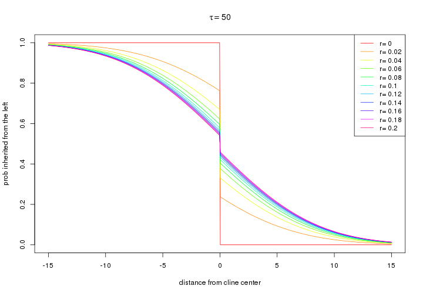

```r
pcline <- function (x,r,tau=1,sigma=1) {
    (1/2)*( 1 - sign(x)*zeta(x=x/sqrt(tau*sigma^2),r=r*tau) )
}
xx <- seq(-15,15,length.out=500)
for (tau in c(5,50)) {
    plot(xx, pcline(xx,r=1), type='n',
            xlab="distance from cline center", ylab="prob inherited from the left",
            main=as.expression(substitute(tau==mytau,list(mytau=tau))) )
    rr <- seq(0,0.2,length.out=11)
    pp <- sapply( rr, function (r) { pcline(xx,r=r,tau=tau) } )
    matplot(xx,pp,type='l',lty=1,col=rainbow(length(rr)),add=TRUE)
    legend("topright",lty=1,col=rainbow(length(rr)),legend=paste("r=",rr))
}
```

# Adjusting for cline width

Above, we were approximating the time that a reflecting lineage spends in a small interval near zero by the local time at zero multiplied by the width of the interval. In fact, when the lineage is at $x$, the lineage recombines to the other background in a given generation with probability equal to the recombination rate multiplied by the probability of being found in a heterozygote. If $p_{AB}(x)$ is the local fraction of heterozygotes, and heterozygotes have relative fecundity $1-s$, then the probability of being in a heterozygote is $(1-s)p_{AB}(x)/((1-s)p_{AB}(x)+2p_{AA}(x))$; if diploid genotypes are assorted randomly, then $p_{AB} = 2p(1-p)$ and $p_{AA}=p^2$, so the probability that an $A$ lineage passes through a heterozygote in a given generation is
$$\begin{align*}
f_H(x)
&=
\frac{ (1-s)p(x)(1-p(x)) }{ p(x)^2 + (1-s) p(x) (1-p(x)) }
&=
\frac{ (1-s)(1-p(x)) }{ p(x) + (1-s) (1-p(x)) } \\
&=
\frac{ (1-s)(1-p(x)) }{ 1 - s (1-p(x)) } .
\end{align*}$$

Bazykin's approximation to a cline is
$$p(x) = \frac{1}{2} (1+\tanh(-2x\sqrt{s}/\sigma))$$
Here's what that looks like:

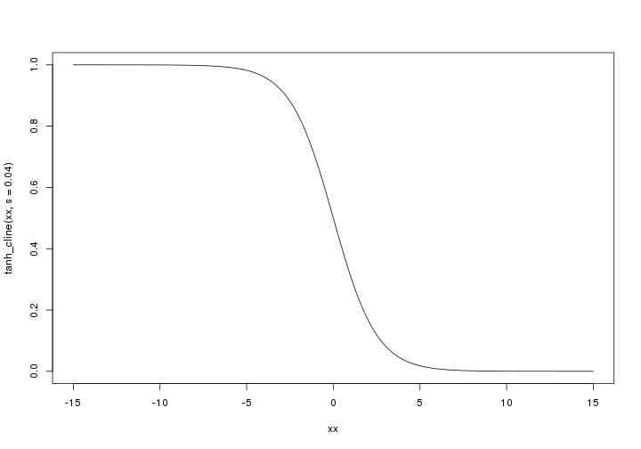

```r
tanh_cline <- function (x,s,sigma=1) {
    (1/2)*(1+tanh(-2*x*sqrt(s)/sigma))
}
fH <- function (x,s,pfn=tanh_cline,...) {
    px <- pfn(x,s=s,...)
    ( (1-s)*(1-px) )/( 1 - s*(1-px) )
}
plot(xx, tanh_cline(xx,s=0.04), type='l' )
```

A lineage does something a bit more complicated, but let's just run a random walk with drift equal to the logarithmic derivative of $p(x)$, i.e.,
$$\begin{align*}
\partial_x \log(p(x))
&= -\frac{2\sqrt{s}}{\sigma}
\frac{1-\tanh^2(-2x\sqrt{s}/σ)}{1+\tanh(-2x\sqrt{s}/σ)} .
\end{align*}$$

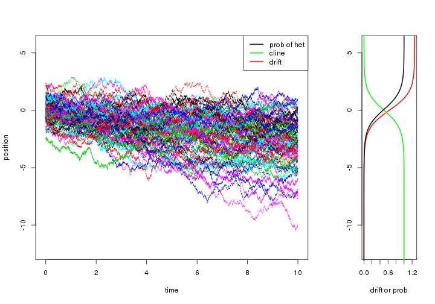

```r
drift <- function (x,s,sigma=1) {
    -(2*sqrt(s)/sigma) * (1-tanh(-2*x*sqrt(s)/sigma)^2) / (1+tanh(-2*x*sqrt(s)/sigma))
}
nwalks <- 1e4
ntimes <- 3e3
total.time <- 10
s <- 0.1
dt <- total.time/ntimes
# put the noise in rws
rws <- rbind( rnorm(nwalks), # initial conditions
             matrix( rnorm(nwalks*(ntimes-1)), nrow=(ntimes-1), ncol=nwalks ) )
# and then integrate over it
for (k in 2:ntimes) {
    rws[k,] <- rws[k-1,]+sqrt(dt)*rws[k,]+dt*drift(rws[k-1,],s)
}
layout( t(1:2), widths=c(3,1) )
matplot(seq(0,total.time,length.out=ntimes),rws[,1:80],type='l', ylab='position', xlab='time', ylim=range(rws) )
legend("topright",lwd=2,legend=c("prob of het","cline","drift"),col=c("black","green","red"))
plot( (-1)*drift(xx,s=s), xx, col='red', lwd=2, type='l', ylim=range(rws), ylab='', xlab='drift or prob' )
lines( tanh_cline(xx,s=s), xx, col='green', lwd=2 )
lines( (1-s)*(1-tanh_cline(xx,s=s))/(1-s*(1-tanh_cline(xx,s=s))), xx, lwd=2 )
```

The cline is in green and the local probability of being in a heterozygote is in black; the drift (multiplied by $-1$) is in red.

Let's just check that's doing the right thing:

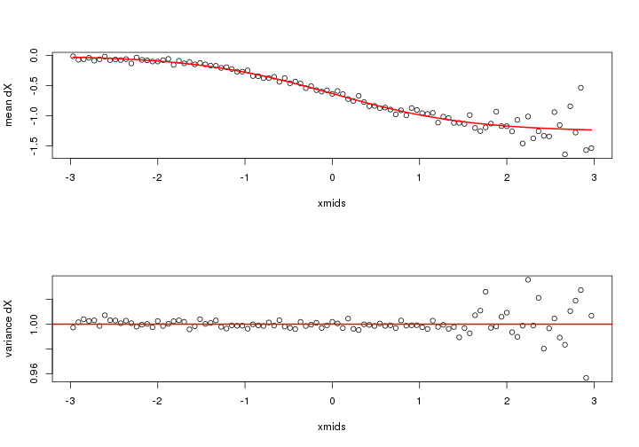

```r
xbreaks <- seq(-3,3,length.out=100)
xmids <- xbreaks[-1]-diff(xbreaks)/2
dX <- apply(rws,2,diff)
Xmeans <- tapply( dX, cut(rws[-nrow(rws),],breaks=xbreaks), mean )
Xvar <- tapply( dX, cut(rws[-nrow(rws),],breaks=xbreaks), var )
layout(1:2)
plot(xmids,Xmeans/dt,ylab="mean dX")
lines(xmids, drift(xmids,s), col='red', lwd=2)
plot(xmids,Xvar/dt,ylab="variance dX")
abline(h=1,col='red',lwd=2)
```

**Comparison to zero-width cline:** Let's start a bunch of random walks sorta far from the cline center, and look at the distribution of the time spend in heterozygotes.

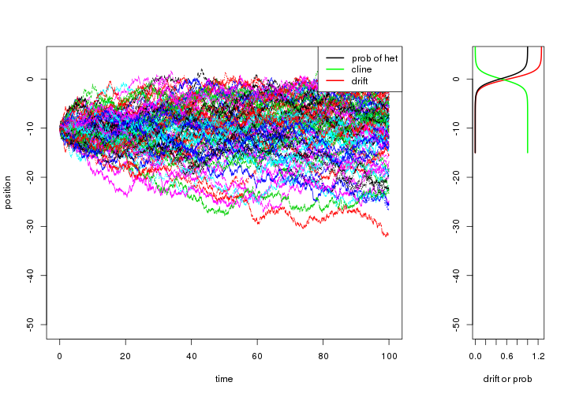

```r
nwalks <- 1e4
ntimes <- 3e3
total.time <- 100
s <- 0.1
dt <- total.time/ntimes
# put the noise in rws
rws <- rbind( -10, # initial conditions
             matrix( rnorm(nwalks*(ntimes-1)), nrow=(ntimes-1), ncol=nwalks ) )
# and then integrate over it
for (k in 2:ntimes) {
    rws[k,] <- rws[k-1,]+sqrt(dt)*rws[k,]+dt*drift(rws[k-1,],s)
}
layout( t(1:2), widths=c(3,1) )
matplot(seq(0,total.time,length.out=ntimes),rws[,1:80],type='l', ylab='position', xlab='time', ylim=range(rws) )
legend("topright",lwd=2,legend=c("prob of het","cline","drift"),col=c("black","green","red"))
plot( (-1)*drift(xx,s=s), xx, col='red', lwd=2, type='l', ylim=range(rws), ylab='', xlab='drift or prob' )
lines( tanh_cline(xx,s=s), xx, col='green', lwd=2 )
lines( (1-s)*(1-tanh_cline(xx,s=s))/(1-s*(1-tanh_cline(xx,s=s))), xx, lwd=2 )
```

Here is the distribution of $T=\int_0^{100} f_H(X_t) dt$:

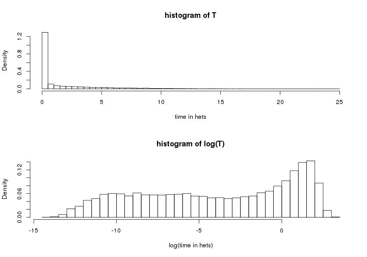

```r
het.time <- dt*colSums( fH(rws,s=s) )
layout(1:2)
hist( het.time, breaks=50, xlab="time in hets", freq=FALSE, main="histogram of T" )
hist( log(het.time), breaks=50, xlab="log(time in hets)", freq=FALSE , main="histogram of log(T)")
```